# Jurimetria

Análise de Decisões de Admissibilidade de REsp pela 1ª Vice-Presidência do TJPR utilizando Técnicas de Ciência de Dados

Alceu Eilert Nascimento (Orientador: Prof. Dr. André Ricardo Abed Grégio)

## Objetivos do Projeto

1. Coletar **148 mil decisões judiciais** do TJPR sobre admissibilidade de recurso especial.
2. Processar, organizar e armazenar os dados em **DuckDB** de Mühleisen and Raasveldt (2024).
3. Criar um website para disponibilização do banco para outros pesquisadores.
4. Analisar dados com algoritmos como **Apriori** de Agrawal and Srikant (1994) e grafos paralelos.
5. Identificar características que influenciam os resultados de admissibilidade de recursos especiais.

## Desafios de Coleta e Extração

- **Origens**:
  - Principal: [TJPR website](https://portal.tjpr.jus.br/jurisprudencia/) de jurisprudência.
  - Complementar: [DataJud do CNJ](https://www.cnj.jus.br/sistemas/datajud/)
- **Formato**: Páginas `.html` semi-estruturadas (TJPR) e API com saida em `.json`.
- **Conteúdo**: Dados cadastrais dos processos e conteudo das decisoes.
- **Desafios**:
  - Dados não estruturados e falta de APIs.
  - Limites de requisições e inconsistências no formato HTML.

## Etapas do Desenvolvimento

### 1. Construção de um Webcrawler

- Linguagem: **Python**.
- Bibliotecas: **Selenium** e **BeautifulSoup**.
- Procedimentos:
  - Navegação automatizada.
  - Controle de erros e retries.
  - Armazenamento em JSON (1:1).

[figure not shown]

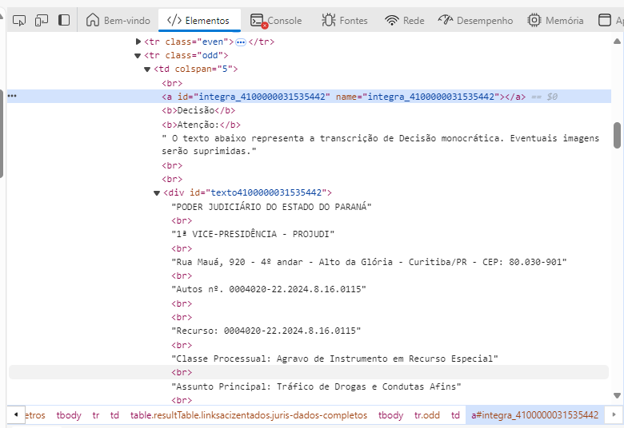

```
[
    {
        "id": "4100000027264661",
        "numeroProcesso": "0002680-31.2023.8.16.0001",
        "descricaoClasse": "",
        "nomeOrgaoJulgador": "18ª Câmara Cível",
        "relator": "substituta luciane bortoleto",
        "dataPublicacao": "Thu Feb 29 00:00:00 BRT 2024",
        "ementa": "APELAÇÕES CÍVEIS...",
        "tipoDeDecisao": "Acórdão",
        "dataDecisao": "Wed Feb 28 00:00:00 BRT 2024",
        "decisao": "VISTOS, relatados e discutidos ....
```

## Etapas do Desenvolvimento

### 2. Processamento e Consolidação

- Parsing com **BeautifulSoup**.
- Limpeza e padronização de dados.
- Agregar dados complementares (DataJud)
- Banco **DuckDB**:
  - Importação dos dados `.json`.
  - Estruturação com índices e backups.

## Análise de Dados

1. **Algoritmo Apriori**:
   - Descobrir padrões entre características e resultados de decisões.
   - Utilização de métricas como suporte, confiança e lift.
2. **Grafos Paralelos**:
   - Visualização multidimensional.
   - Identificar padrões e tendências em decisões judiciais.

## Resultados Esperados e Conclusão

- Banco de dados consolidado e website funcional.
- Identificação de padrões nas decisões judiciais.
- Integração de técnicas de ciência de dados com estudos jurídicos.
- Transparência no processo decisório do sistema judiciário.
- Contribuição para a eficiência e clareza nas admissibilidades recursais.

## Referências

DSBD Turma 2024-1 | Apresentação do projeto de pesquisa

AGRAWAL, R.; SRIKANT, R. **VLDB ´94**Santiago: 1994

MÜHLEISEN, H.; RAASVELDT, MA. **[Duckdb: DBI package for the DuckDB database management system](https://r.duckdb.org/)**. [s.l: s.n.].